# Data Story 2

[figure not shown]

[figure not shown]

[figure not shown]

[figure not shown]

# Introduction

### Main Goal of this Story Board

**Main Question:** Is rising seafood demand compatible with SDG 14 ?

## Right Column

### Global Seafood Consumption Per Person (1961–2022)

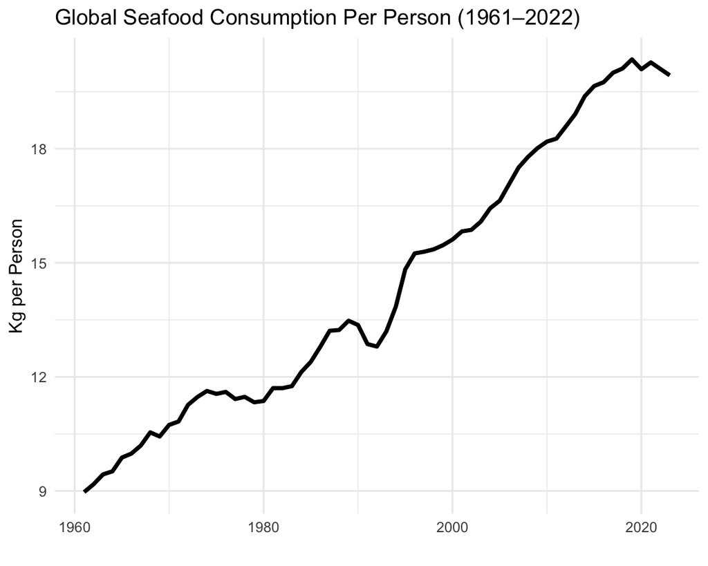

### Average Consumption (2000–2022)

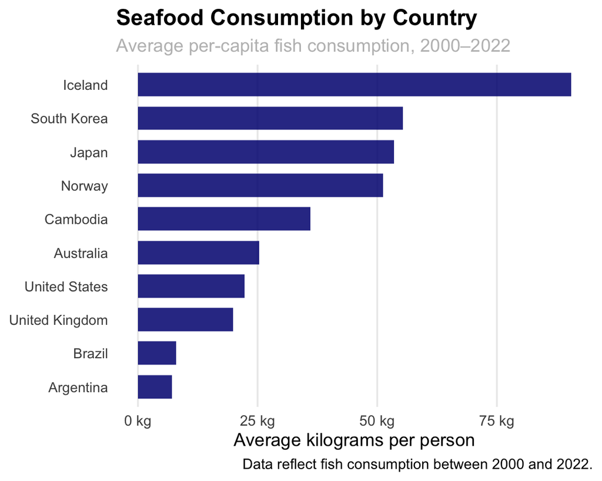

# Trends

### Iceland vs Argentina

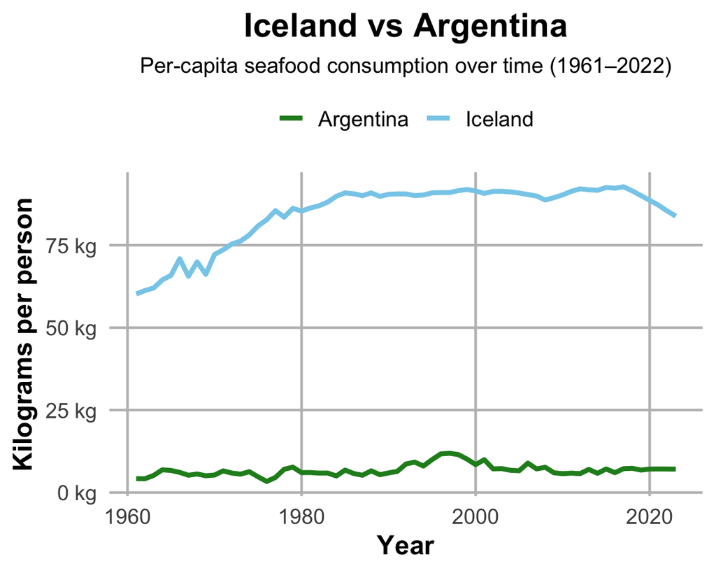

### Iceland Consumes Far More Seafood Than Argentina

Iceland and Argentina illustrate the inequality in global seafood consumption. Throughout the entire period, Iceland maintains consistently high per-capita seafood intake, reflecting its coastal geography, fishing-based economy, and strong cultural reliance on marine protein. Argentina, by contrast, remains relatively low and stable over time. This persistent gap highlights how seafood consumption is shaped not only by income, but also by geography, trade access, and dietary traditions. From an SDG 14 perspective, countries with historically high consumption levels may exert sustained pressure on marine ecosystems, while lower-consuming nations are less directly tied to global fisheries demand.

## Right Column

### Japan vs Cambodia

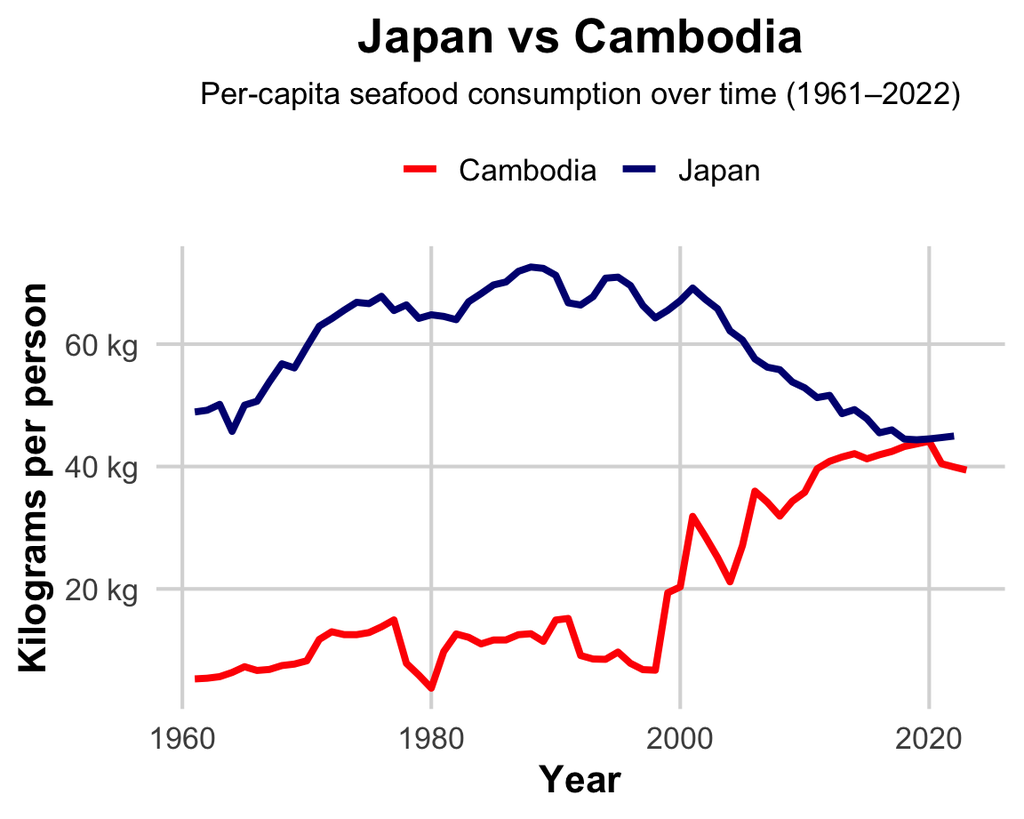

# Data Tables

## Left column {data-width=650}

### Data Table 1

**Long-Term Average Fish Consumption by Country (1961–2022)**

| **Country** | **Average Fish Consumption (kg per capita)** |
| --- | --- |
| Iceland | 84.8 |
| Japan | 59.8 |
| Norway | 46.4 |
| South Korea | 43.8 |
| Cambodia | 19.9 |
| Australia | 19.6 |
| United Kingdom | 19.3 |
| United States | 19.3 |
| Brazil | 6.9 |
| Argentina | 6.8 |

Table 1. Long-Term Average Fish Consumption by Country (1961–2022). This table presents the average per-capita fish and seafood consumption (in kilograms per year) across all available years for selected countries. The values reflect long-term dietary patterns and highlight cross-country differences in reliance on marine protein sources.

### Data Table 2

**Change in Fish Consumption Per Capita (1961 vs 2022)**

| Country | 1961 | 2022 | Change |
| --- | --- | --- | --- |
| South Korea | 12.696435 | 52.789997 | 40.093562 |
| Cambodia | 5.299799 | 39.920000 | 34.620201 |
| Iceland | 60.205290 | 85.398200 | 25.192910 |
| Australia | 12.813356 | 24.469994 | 11.656638 |
| Norway | 40.675083 | 49.670033 | 8.994950 |
| United States | 13.430598 | 22.070002 | 8.639404 |
| Brazil | 4.633639 | 8.220000 | 3.586361 |
| Argentina | 4.216822 | 7.129999 | 2.913177 |
| United Kingdom | 19.883354 | 17.830002 | -2.053352 |
| Japan | 48.917130 | 44.980457 | -3.936673 |

Table 2. This table highlights long-term growth in seafood consumption, which has important implications for marine sustainability and SDG 14 (Life Below Water). Rising consumption levels may increase pressure on global fish stocks and marine ecosystems.

### Data Table 3

| Country | Fish Consumption (kg per capita) |
| --- | --- |
| Iceland | 85.40 |
| South Korea | 52.79 |
| Norway | 49.67 |
| Japan | 44.98 |
| Cambodia | 39.92 |
| Australia | 24.47 |
| United States | 22.07 |
| United Kingdom | 17.83 |
| Brazil | 8.22 |
| Argentina | 7.13 |

## Right column

### How many kilograms did a average person consume in 1961?

8.969643 kg

### How many kilograms did a average person consume in 2022?

20.1 kg

# Map: Average Seafood Consumption Per Person (1961–2022)

### **Map Analysis**

- This map reveals that high seafood consumption is heavily concentrated in coastal and maritime nations.
- Iceland stands out dramatically, reflecting its deep economic and cultural reliance on fishing industries.
- Other high-consuming countries, such as Japan, South Korea, and Norway, also share strong historical ties to marine resources. In contrast, larger continental nations like Argentina and Brazil display comparatively lower per-capita intake.
- The geographic clustering highlights how access to coastlines, fishing infrastructure, and maritime trade routes shape dietary patterns. From an SDG 14 perspective, this concentration suggests that pressure on marine ecosystems is not evenly distributed across the globe. Instead, it is driven largely by specific coastal economies whose consumption patterns are deeply embedded in national identity and economic structure.

## Right column

[interactive chart not shown]